# Assignment 7

Ted Henson

October 24, 2018

shot_x: The X location of the shooter. The center of the hoop is zero. Positive is towards right sideline. Negative is towards the left sideline

shot_y: The Y location of the shooter. The center of the hoop is zero. Positive is towards midcourt. Negative is towards the baseline.

shooter_velocity_ft_sec: Velocity of the shooter in feet per second.

shooter_velocity_angle: The direction the shooter is traveling in degrees. Zero is the line between the hoop and the shooter. Positive angles are to the right of the shooter. Negative angles are to the left.

dribbles_before: The number of dribbles by the shooter prior to shooting. made 1 if shot was made, 0 if missed.

defender_distance: Distance between defender and shooter in feet.

defender_angle: The angle in degrees between the hoop and the defender with the shooter as the vertex. To the right is positive.

defender_velocity_ft_sec: Velocity of the defender in feet per second.

defender_velocity_angle: The direction the defender is traveling in degrees. The angle between the shooter and defender is 0. Positive angles mean the player is moving to the right of shooter when viewed from defender’s position.

# Part A

```r
setwd("~/shots")
library(tidyverse)
shots <- read.csv(file = "shots.csv", header = TRUE, stringsAsFactors = F, fill = T)
shots$r <- sqrt(shots$shot_x^2 + shots$shot_y^2)



set.seed(101)
split <- sample(nrow(shots), 8000)
train <- shots[split,]
test <- shots[-split,]
library(boot)
library(glmnet)
library(MASS)
fit <- glm(made ~ r , data = shots, family = 'binomial')
summary(fit)
```

```
##
## Call:
## glm(formula = made ~ r, family = "binomial", data = shots)
##
## Deviance Residuals:
##     Min       1Q   Median       3Q      Max
## -1.3747  -0.9658  -0.7824   1.1036   2.6190
##
## Coefficients:
##              Estimate Std. Error z value Pr(>|z|)
## (Intercept)  0.455589   0.036830   12.37   <2e-16 ***
## r           -0.056003   0.002082  -26.90   <2e-16 ***
## ---
## Signif. codes:  0 '***' 0.001 '**' 0.01 '*' 0.05 '.' 0.1 ' ' 1
##
## (Dispersion parameter for binomial family taken to be 1)
##
##     Null deviance: 13456  on 9999  degrees of freedom
## Residual deviance: 12588  on 9998  degrees of freedom
## AIC: 12592
##
## Number of Fisher Scoring iterations: 4
```

# Part B

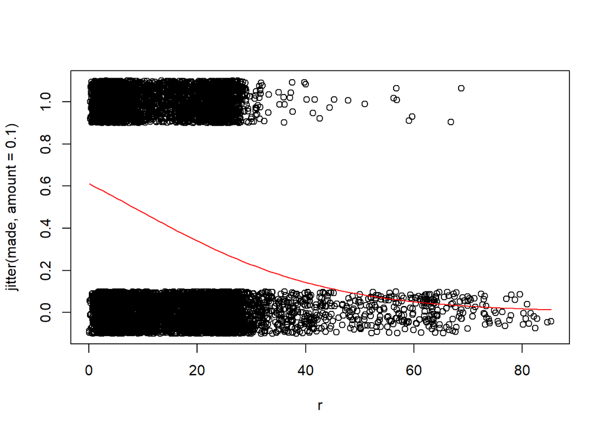

```r
B0 = summary(fit)$coef[1]
B1 = summary(fit)$coef[2]


plot(jitter(made, amount = .1)~r,data=shots)
curve(exp(B0+B1*x)/(1+exp(B0+B1*x)),add=TRUE, col="red")
```

# Part C

```r
exp(cbind("Odds Ratio" = coef(fit), confint.default(fit, level = .95)))
```

```
##             Odds Ratio     2.5 %    97.5 %
## (Intercept)  1.5771013 1.4672693 1.6951547
## r            0.9455363 0.9416859 0.9494025
```

# Part D

```r
G = 1- pchisq(13456 - 12588, 1)
G
```

```
## [1] 0
```

Our null hypothesis is that using the mean of field goal percentage is more effective than using shooting distance to predict the probability.The alternative is that shooting distance is a signficant predictor. The G statistic is zero, so our model is very significant.

## Second Predictor

```r
def <- glm(made ~ defender_distance, data = shots, family = 'binomial')
summary(def)
```

```
##
## Call:
## glm(formula = made ~ defender_distance, family = "binomial",
##     data = shots)
##
## Deviance Residuals:
##     Min       1Q   Median       3Q      Max
## -1.0314  -1.0150  -0.9987   1.3469   1.5488
##
## Coefficients:
##                    Estimate Std. Error z value Pr(>|z|)
## (Intercept)       -0.353718   0.035446  -9.979   <2e-16 ***
## defender_distance -0.012465   0.006729  -1.852    0.064 .
## ---
## Signif. codes:  0 '***' 0.001 '**' 0.01 '*' 0.05 '.' 0.1 ' ' 1
##
## (Dispersion parameter for binomial family taken to be 1)
##
##     Null deviance: 13456  on 9999  degrees of freedom
## Residual deviance: 13453  on 9998  degrees of freedom
## AIC: 13457
##
## Number of Fisher Scoring iterations: 4
```

# Part B

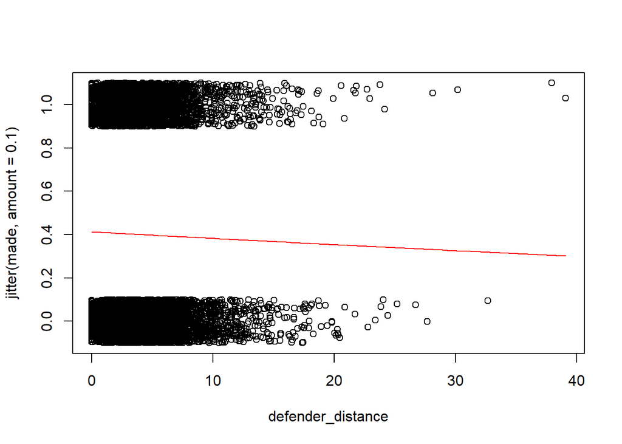

```r
B0 = summary(def)$coef[1]
B1 = summary(def)$coef[2]




plot(jitter(made, amount = .1)~defender_distance,data=shots)
curve(exp(B0+ B1*x )/(1+exp(B0+B1*x)),add=TRUE, col="red")
```

# Part C

```r
exp(cbind("Odds Ratio" = coef(def), confint.default(def, level = .95)))
```

```
##                   Odds Ratio     2.5 %    97.5 %
## (Intercept)        0.7020731 0.6549542 0.7525818
## defender_distance  0.9876122 0.9746718 1.0007243
```

# Part D

```r
G = 1- pchisq(13456 - 13453, 1)
G
```

```
## [1] 0.08326452
```

Our null hypothesis is that using the mean of field goal percentage is more effective than using defender distance to predict the probability.The alternative is that defender distance is effective. The G statistic is .08, so our model is somewhat effective.

# Multiple

```r
mult <- glm(made ~ . , data = shots, family = 'binomial')
step <- stepAIC(mult, direction = "both")
```

```
## Start:  AIC=12388.5
## made ~ shot_x + shot_y + shooter_velocity_ft_sec + shooter_velocity_angle +
##     dribbles_before + defender_distance + defender_angle + defender_velocity_ft_sec +
##     defender_velocity_angle + r
##
##                            Df Deviance   AIC
## - shot_x                    1    12366 12386
## - defender_velocity_angle   1    12367 12387
## - shooter_velocity_angle    1    12367 12387
## - shot_y                    1    12367 12387
## - defender_angle            1    12367 12387
## <none>                           12366 12388
## - shooter_velocity_ft_sec   1    12371 12391
## - defender_velocity_ft_sec  1    12375 12395
## - dribbles_before           1    12399 12419
## - defender_distance         1    12498 12518
## - r                         1    12668 12688
##
## Step:  AIC=12386.5
## made ~ shot_y + shooter_velocity_ft_sec + shooter_velocity_angle +
##     dribbles_before + defender_distance + defender_angle + defender_velocity_ft_sec +
##     defender_velocity_angle + r
##
##                            Df Deviance   AIC
## - defender_velocity_angle   1    12367 12385
## - shooter_velocity_angle    1    12367 12385
## - shot_y                    1    12367 12385
## - defender_angle            1    12367 12385
## <none>                           12366 12386
## + shot_x                    1    12366 12388
## - shooter_velocity_ft_sec   1    12371 12389
## - defender_velocity_ft_sec  1    12375 12393
## - dribbles_before           1    12399 12417
## - defender_distance         1    12498 12516
## - r                         1    12668 12686
##
## Step:  AIC=12384.7
## made ~ shot_y + shooter_velocity_ft_sec + shooter_velocity_angle +
##     dribbles_before + defender_distance + defender_angle + defender_velocity_ft_sec +
##     r
```

[output cut: 49 more lines]

[output not shown]

```r
summary(step)
```

```
##
## Call:
## glm(formula = made ~ shooter_velocity_ft_sec + dribbles_before +
##     defender_distance + defender_velocity_ft_sec + r, family = "binomial",
##     data = shots)
##
## Deviance Residuals:
##     Min       1Q   Median       3Q      Max
## -2.2138  -0.9993  -0.6995   1.1272   2.8818
##
## Coefficients:
##                           Estimate Std. Error z value Pr(>|z|)
## (Intercept)               0.328429   0.068501   4.795 1.63e-06 ***
## shooter_velocity_ft_sec  -0.013928   0.007008  -1.987  0.04688 *
## dribbles_before          -0.030928   0.005554  -5.569 2.57e-08 ***
## defender_distance         0.096580   0.008619  11.205  < 2e-16 ***
## defender_velocity_ft_sec  0.018750   0.006630   2.828  0.00468 **
## r                        -0.073974   0.002801 -26.408  < 2e-16 ***
## ---
## Signif. codes:  0 '***' 0.001 '**' 0.01 '*' 0.05 '.' 0.1 ' ' 1
##
## (Dispersion parameter for binomial family taken to be 1)
##
##     Null deviance: 13456  on 9999  degrees of freedom
## Residual deviance: 12368  on 9994  degrees of freedom
## AIC: 12380
##
## Number of Fisher Scoring iterations: 4
```

```r
G = 1- pchisq(13456 - 12368, 5)
G
```

```
## [1] 0
```

Our null is that the mean of field goal percentage is just as good as using the predictors in our model. The alternative is that the predictors are significant. The G statistic is 0, so our model is very effective.

# Part C

Distance, defender distance, our intercept, and dribbles before are significant at the third level. Shooter velocity is only significant at the first level. Defender velocity is significant at the second level.

# Part D

```r
anova(fit, step)
```

```
## Analysis of Deviance Table
##
## Model 1: made ~ r
## Model 2: made ~ shooter_velocity_ft_sec + dribbles_before + defender_distance +
##     defender_velocity_ft_sec + r
##   Resid. Df Resid. Dev Df Deviance
## 1      9998      12588
## 2      9994      12368  4   219.92
```

```r
anova(def, step)
```

```
## Analysis of Deviance Table
##
## Model 1: made ~ defender_distance
## Model 2: made ~ shooter_velocity_ft_sec + dribbles_before + defender_distance +
##     defender_velocity_ft_sec + r
##   Resid. Df Resid. Dev Df Deviance
## 1      9998      13453
## 2      9994      12368  4   1084.8
```

```r
G = 1- pchisq(12588 - 12368, 4)
G
```

```
## [1] 0
```

```r
G = 1- pchisq(13453 - 12368, 4)
G
```

```
## [1] 0
```

Our null hypotheses are that just using defender distance or shooter distance is just as significant as using more variables. The alternative is that including other variables improves the model. Both G statistics are zero, so the multiple glm is more effective than both simple logistic models.

# Second Order

```r
order <- glm(made ~ I(defender_distance^2) + I(r^2) + r*defender_distance, family = 'binomial', data = shots)
summary(order)
```

```
##
## Call:
## glm(formula = made ~ I(defender_distance^2) + I(r^2) + r * defender_distance,
##     family = "binomial", data = shots)
##
## Deviance Residuals:
##     Min       1Q   Median       3Q      Max
## -2.1004  -0.9860  -0.7079   1.1564   2.8943
##
## Coefficients:
##                          Estimate Std. Error z value Pr(>|z|)
## (Intercept)            -0.1295682  0.0670054  -1.934 0.053150 .
## I(defender_distance^2) -0.0069045  0.0009703  -7.116 1.11e-12 ***
## I(r^2)                  0.0005100  0.0001462   3.488 0.000486 ***
## r                      -0.0781741  0.0060815 -12.855  < 2e-16 ***
## defender_distance       0.2965990  0.0237533  12.487  < 2e-16 ***
## r:defender_distance    -0.0041891  0.0008602  -4.870 1.12e-06 ***
## ---
## Signif. codes:  0 '***' 0.001 '**' 0.01 '*' 0.05 '.' 0.1 ' ' 1
##
## (Dispersion parameter for binomial family taken to be 1)
##
##     Null deviance: 13456  on 9999  degrees of freedom
## Residual deviance: 12334  on 9994  degrees of freedom
## AIC: 12346
##
## Number of Fisher Scoring iterations: 5
```

# Part A

```r
G = 1- pchisq(13456  - 12334, 5)
G
```

```
## [1] 0
```

Our null hypothesis is that using just the mean of field goal percentage is just as effective as using these predictors. The alternative is that it is more effective to include these predictors. The G statistic is zero, so the second order terms are very significant.

# Part B

All of our predictors except for the intercept are significant at the third level.

# Part C

```r
anova(fit, order)
```

```
## Analysis of Deviance Table
##
## Model 1: made ~ r
## Model 2: made ~ I(defender_distance^2) + I(r^2) + r * defender_distance
##   Resid. Df Resid. Dev Df Deviance
## 1      9998      12588
## 2      9994      12334  4    253.6
```

```r
anova(def, order)
```

```
## Analysis of Deviance Table
##
## Model 1: made ~ defender_distance
## Model 2: made ~ I(defender_distance^2) + I(r^2) + r * defender_distance
##   Resid. Df Resid. Dev Df Deviance
## 1      9998      13453
## 2      9994      12334  4   1118.4
```

```r
G1 = 1- pchisq(12588 - 12334, 4)
G2 = 1- pchisq(13453 - 12334, 4)
G1
```

```
## [1] 0
```

```r
G2
```

```
## [1] 0
```

Our null hypotheses are that using no second order variables is just as effective as including them. The alternative is that it is more effective to include them. Both G statistics are zero, so the second order terms are very significant in each.